2012 Presidential Campaign Donations in Ohio

Aaron Rank

========================================================

```
## [1] 129325     18
```

```
##  [1] "cmte_id"           "cand_id"           "cand_nm"
##  [4] "contbr_nm"         "contbr_city"       "contbr_st"
##  [7] "contbr_zip"        "contbr_employer"   "contbr_occupation"
## [10] "contb_receipt_amt" "contb_receipt_dt"  "receipt_desc"
## [13] "memo_cd"           "memo_text"         "form_tp"
## [16] "file_num"          "tran_id"           "election_tp"
```

```
## 'data.frame':    129325 obs. of  18 variables:
##  $ cmte_id          : chr  "C00431171" "C00431171" "C00431171" "C00431171" ...
##  $ cand_id          : chr  "P80003353" "P80003353" "P80003353" "P80003353" ...
##  $ cand_nm          : chr  "Romney, Mitt" "Romney, Mitt" "Romney, Mitt" "Romney, Mitt" ...
##  $ contbr_nm        : chr  "SMITH, STEPHEN C. MR." "SMITH, STEPHEN C. MR." "SMITH, TRAVIS" "STEINER, GREGORY" ...
##  $ contbr_city      : chr  "FINDLAY" "FINDLAY" "UPPER ARLINGTON" "WOOSTER" ...
##  $ contbr_st        : chr  "OH" "OH" "OH" "OH" ...
##  $ contbr_zip       : chr  "458406817" "458406817" "432213322" "446917442" ...
##  $ contbr_employer  : chr  "AQUA-LINE INC." "AQUA-LINE INC." "HMI INC" "FLIGHT BOSS" ...
##  $ contbr_occupation: chr  "BUSINESS OWNER" "BUSINESS OWNER" "SALES" "FABRICATOR" ...
##  $ contb_receipt_amt: num  50 50 100 250 250 100 100 200 100 300 ...
##  $ contb_receipt_dt : chr  "13-AUG-12" "23-AUG-12" "23-AUG-12" "09-AUG-12" ...
##  $ receipt_desc     : chr  "" "" "" "" ...
##  $ memo_cd          : chr  "" "" "" "" ...
##  $ memo_text        : chr  "" "" "" "" ...
##  $ form_tp          : chr  "SA17A" "SA17A" "SA17A" "SA17A" ...
##  $ file_num         : int  896743 896743 896743 896743 896743 896743 896743 896743 896743 896743 ...
##  $ tran_id          : chr  "SA17.1995556" "SA17.2184389" "SA17.2147759" "SA17.1850253" ...
##  $ election_tp      : chr  "P2012" "P2012" "G2012" "P2012" ...
```

### Feature Creation and Addition

### Contribution Amount

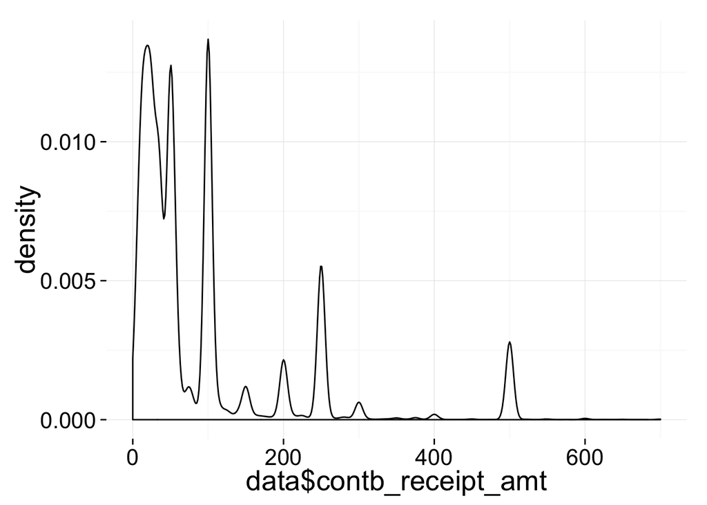

```
## stat_bin: binwidth defaulted to range/30. Use 'binwidth = x' to adjust this.
```

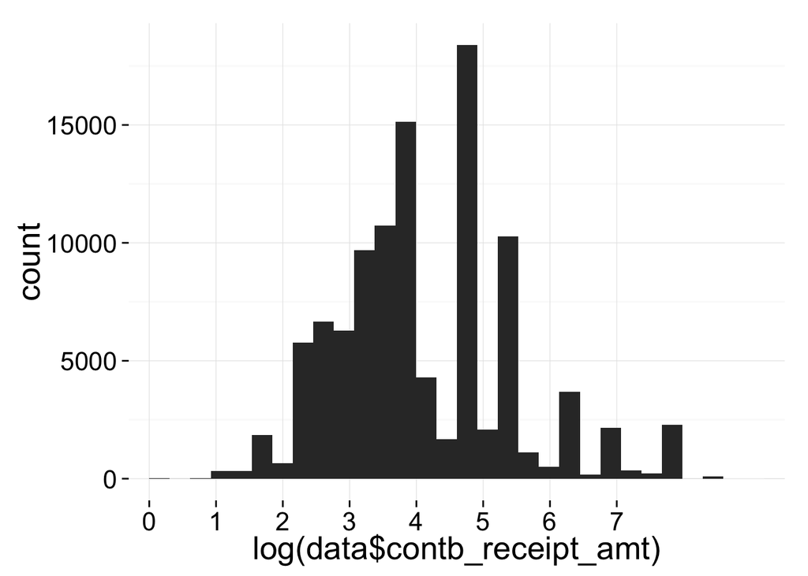

The contribution amount is not normally distributed, it is closer to a log-normal distribution, and is multi-modal. It appears that the most frequent contribution amounts were less than or equal to $100 with a $100 donation being the most frequent. One can also see that the data contains peaks at specific values such as 100, 250, and 500 - this aspect of the data gives it the feeling of being discrete.

### Election Type

```
##
##       G2012     P P2012
##     6 56965     4 47771
```

election_tp tells in which election the donation was made; namely the Primary or General Election which respectively accounted for 45% and 55% of all donations.

### Contributor’s Occupation & Employer

```
## data$contbr_occupation
##       n missing  unique
##  104592     154    4135
##
## lowest : 2ND GRADE TEACHER        3D MODELER               401K SALES               4TH GRADE TEACHER        A/P CLERK
## highest: YOUTH MINISTER           YOUTH MINISTRY           YOUTH SERVICES           YOUTH SERVICES ASSOCIATE ZONE BUSINESS MANAGER
```

```
## data$contbr_employer
##       n missing  unique
##  104416     330   11403
##
## lowest : (SELF) GREEN LEAF LAWN CARE           (SELF) STATE FARM INSURANCE COMPANIES 1 EDI SOURCE, INC                     1 FINANCIAL CORPORATION               1099
## highest: ZOLMET TECHNOLOGIES INC.              ZOO GAMES INC.                        ZUCKERMAN CONSULTING GROUP, INC.      ZUKERMAN DAIKER & LEAR                ZUKERMAN DAIKER LEAR
```

### Contributor’s Population - Newly Created Feature

```
## stat_bin: binwidth defaulted to range/30. Use 'binwidth = x' to adjust this.
```

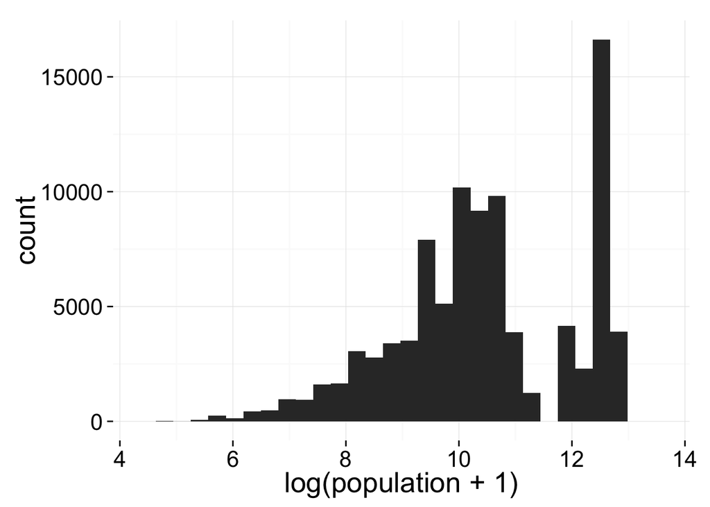

```
##    Min. 1st Qu.  Median    Mean 3rd Qu.    Max.
##      77   13840   37530  173700  297500  822600
```

### Number of Days from the General Election the Contribution was Made - Newly Created Feature

```
## stat_bin: binwidth defaulted to range/30. Use 'binwidth = x' to adjust this.
```

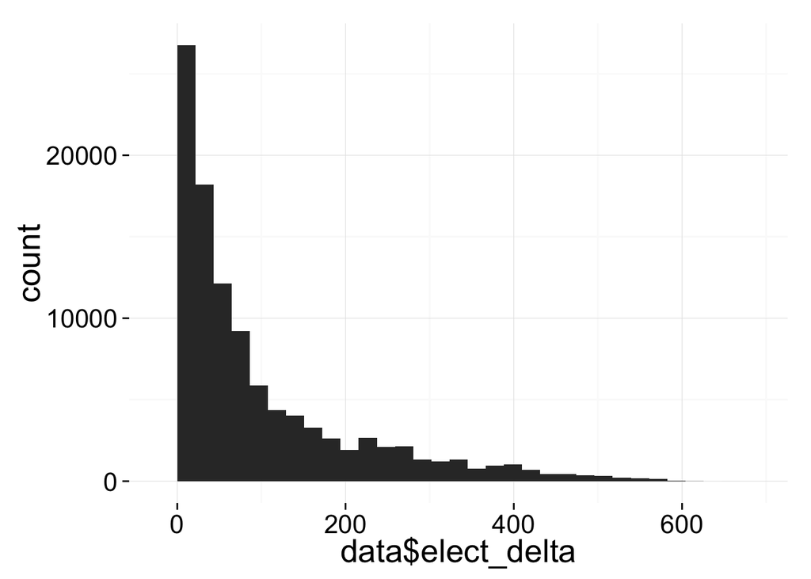

elect_delta follows the log-normal distribution. This makes sense as American’s are typically apathetic towards politics especially when an election is months or years away. The two campaigns were also likely to have ramped up their efforts to solicit contributions as election day neared.

### Candidate’s Party - Newly Created Feature

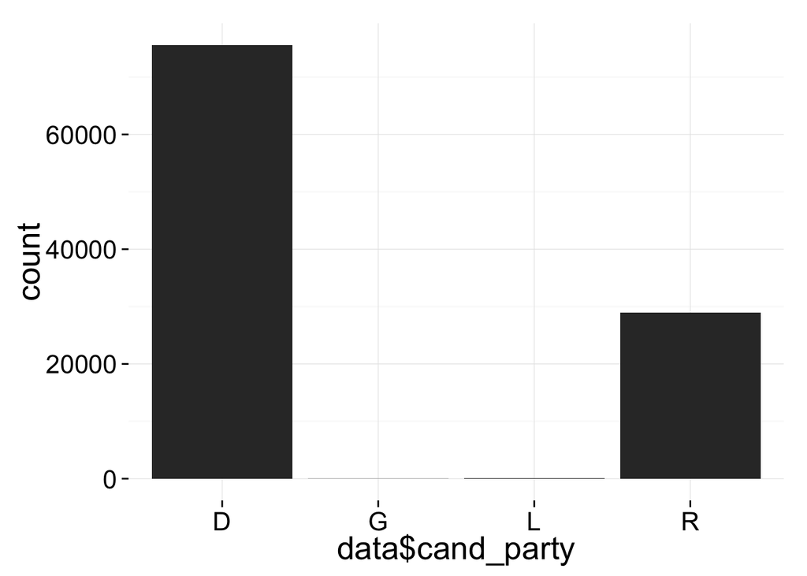

```
## data$cand_party
##       n missing  unique
##  104746       0       4
##
## D (75633, 72%), G (30, 0%), L (100, 0%), R (28983, 28%)
```

Democratic candidates received 72% of donations as opposed to the Republicans 28%. This is interesting because Ohio is typically considered a battle ground state meaning that the voting population is equally split between the two parties.

### Predicted Gender of Contributor - Newly Created Feature

```
##
## female   male
##  51339  53407
```

#### Predicting Gender

I need to predict the gender of the contributors that did not include MR., MRS., or MS. I attempted to use the gender package in R, but it was very slow (it never completed the task, but it had been over 8 hours when I finally stopped it). As such, I decided to use Python’s NLTK library for the task and created a script called classify_gender.py. Running classify_gender.py creates a new csv file (data_gender_predicted.csv) with predicted gender names and prints “You classified 0.7704 correct on the test set” to stdout. After running both python scripts, I loaded the results back into R.

### Included Gender - Did the Contributor Indicate their Gender?

```
##
##     0     1
## 89410 15336
```

Out of the over 100,000 records, only about 15,000 records exist where the contributor provided an indication of their gender by using “MS.”, “MRS.”, or “MR.”. Using the way back machine, I looked at the Obama and Romney donation page on their website - neither seemed to ask for gender nor have a form for the donor to identify their gender.

### Contributor’s Estimated Salary - Newly Created Feature

```
## stat_bin: binwidth defaulted to range/30. Use 'binwidth = x' to adjust this.
```

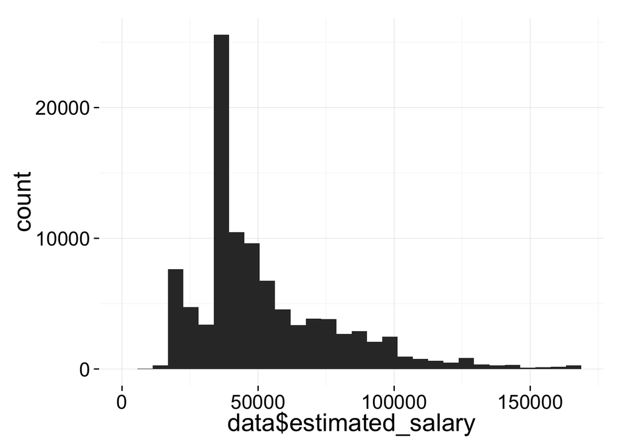

```
## stat_bin: binwidth defaulted to range/30. Use 'binwidth = x' to adjust this.
```

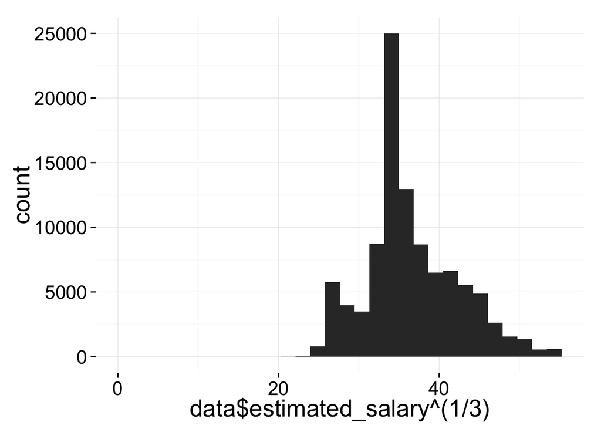

#### Predicting Salaries

Trying to use all of the information provided in the original file and thinking that a person’s salary could have predictive power, I wrote a web scraping script, get_estimated_salaries.py, in Python that gets salary information for different occupations. Indeed.com allows you to enter an occupation and zip code and returns an average salary.

### Multiple Contributions - Newly Created Feature

```
##
##     0     1
## 32290 72456
```

I made the assumption that if a contributor’s name, city, and employer show up more than once, it is the same person and this would indicate that they made multiple contributions.

### What is/are the main feature(s) of interest in your dataset?

I am interested to which political party the contribution was made as I will attempt to build a model to predict this. I believe some of the relevant features will be the amount contributed, when the contribution was made, the gender of the contributor, the location of the contributor, the salary of the contributor, and if the contributor made multiple contributions. It would be nice to know the age of the contributor, but this information is difficult to acquire.

# Bivariate Plots Section

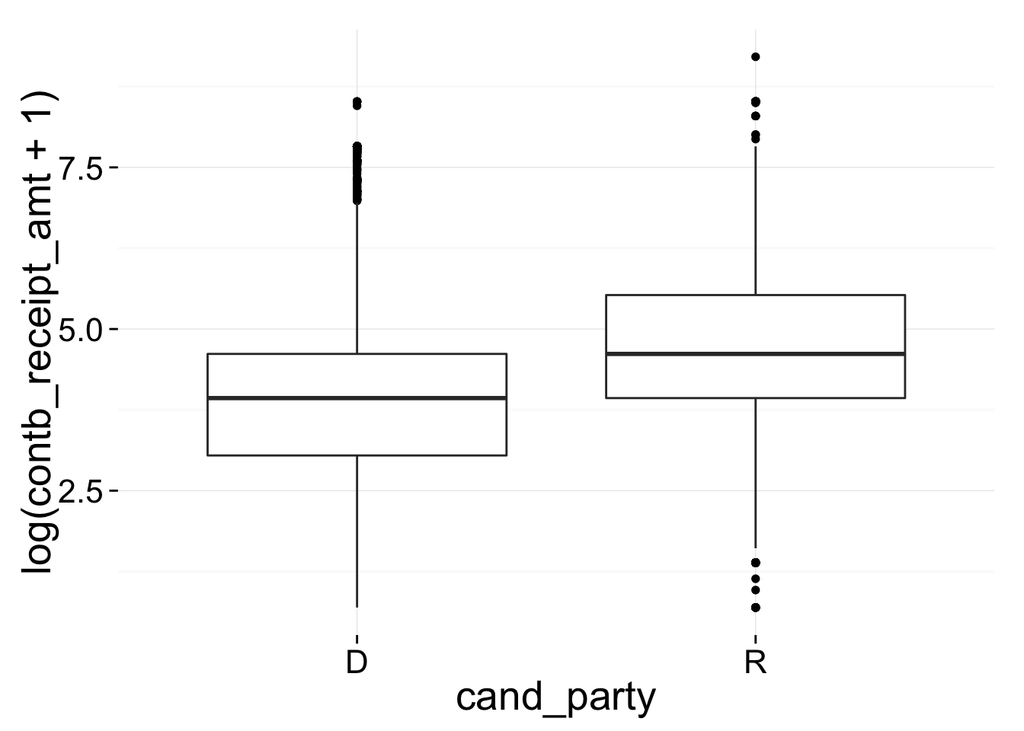

```
## stat_bin: binwidth defaulted to range/30. Use 'binwidth = x' to adjust this.
```

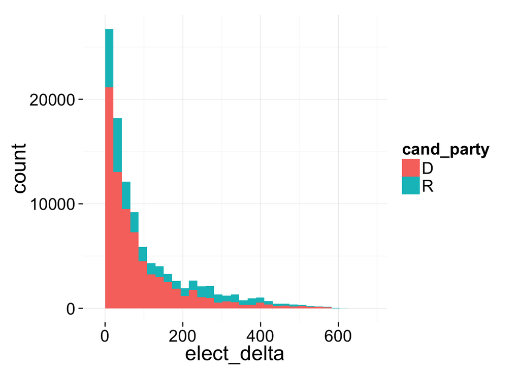

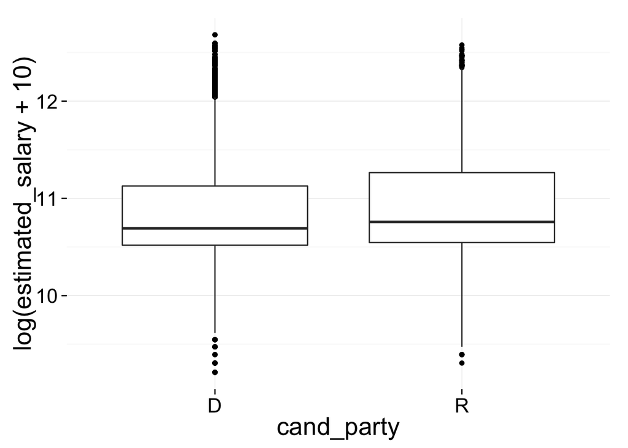

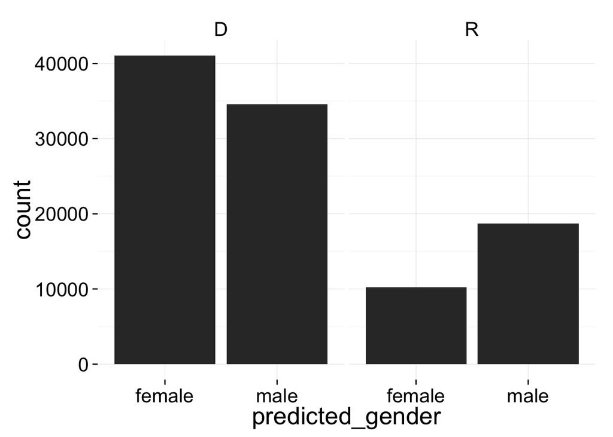

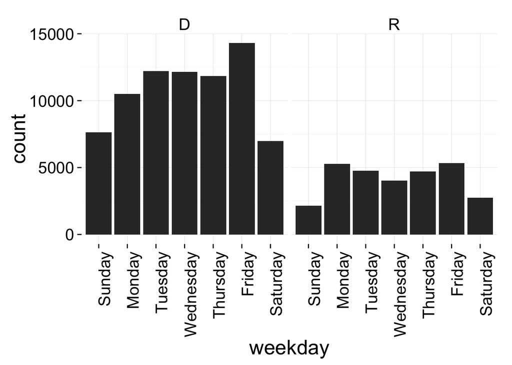

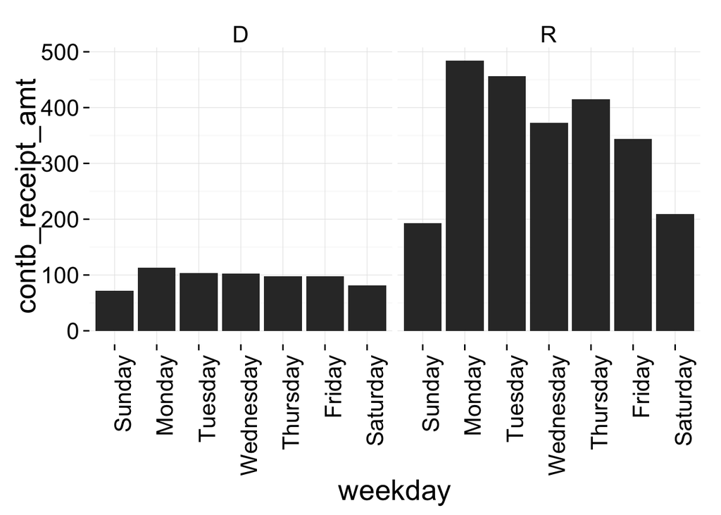

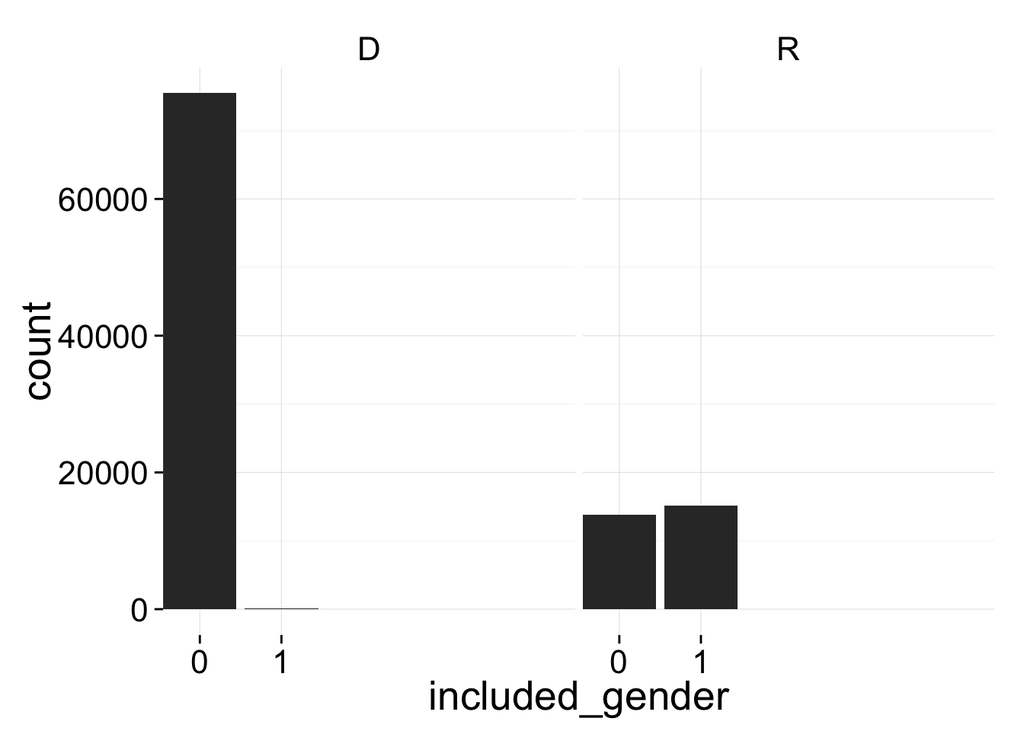

```
##           included_gender
## cand_party     0     1
##          D 75497   136
##          R 13783 15200
```

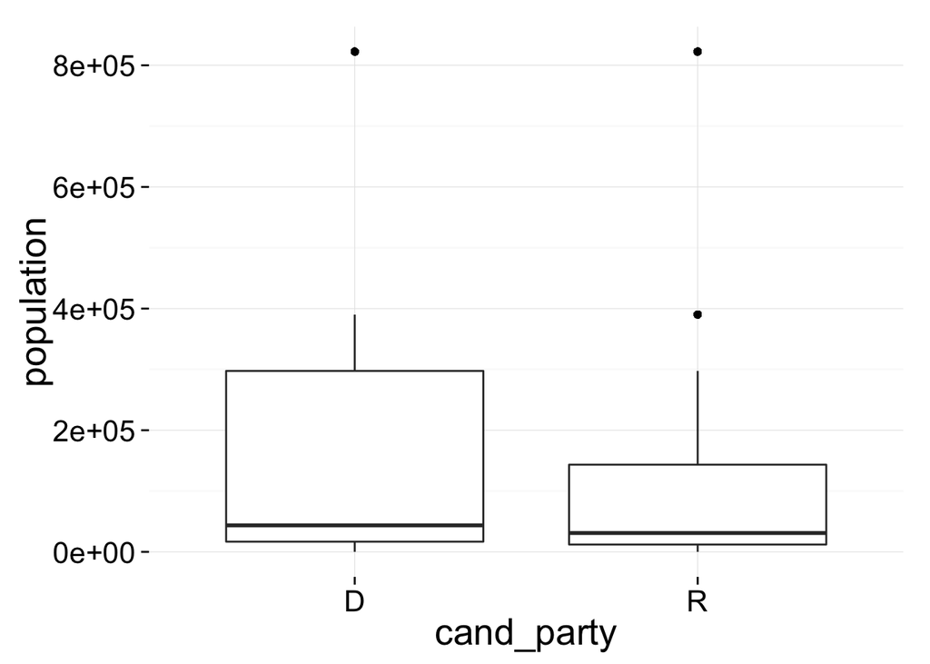

```
## stat_bin: binwidth defaulted to range/30. Use 'binwidth = x' to adjust this.
```

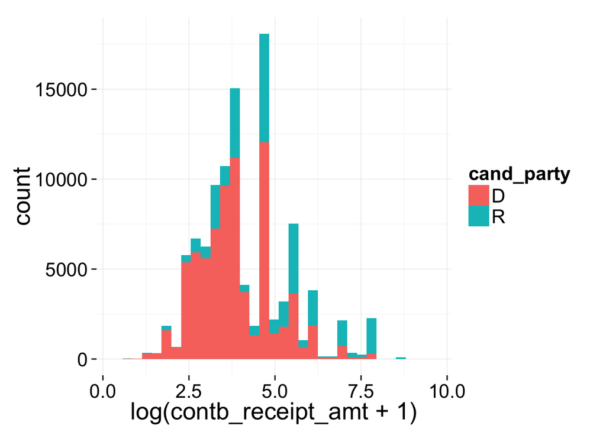

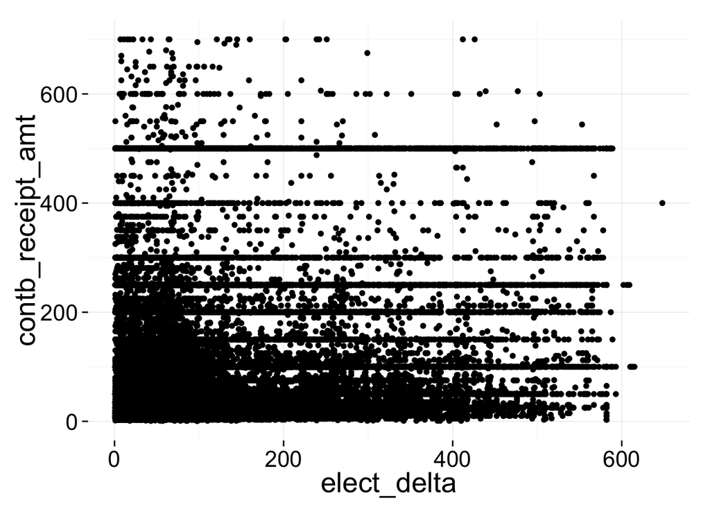

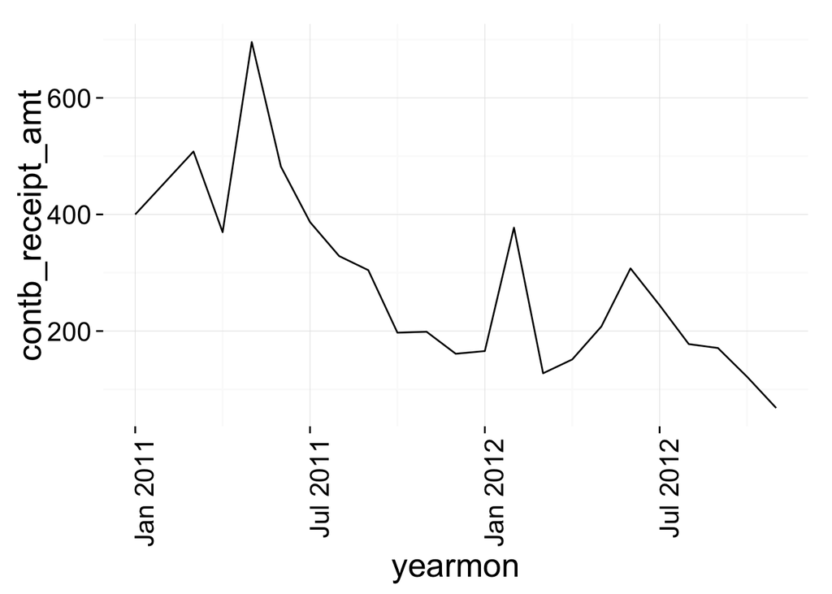

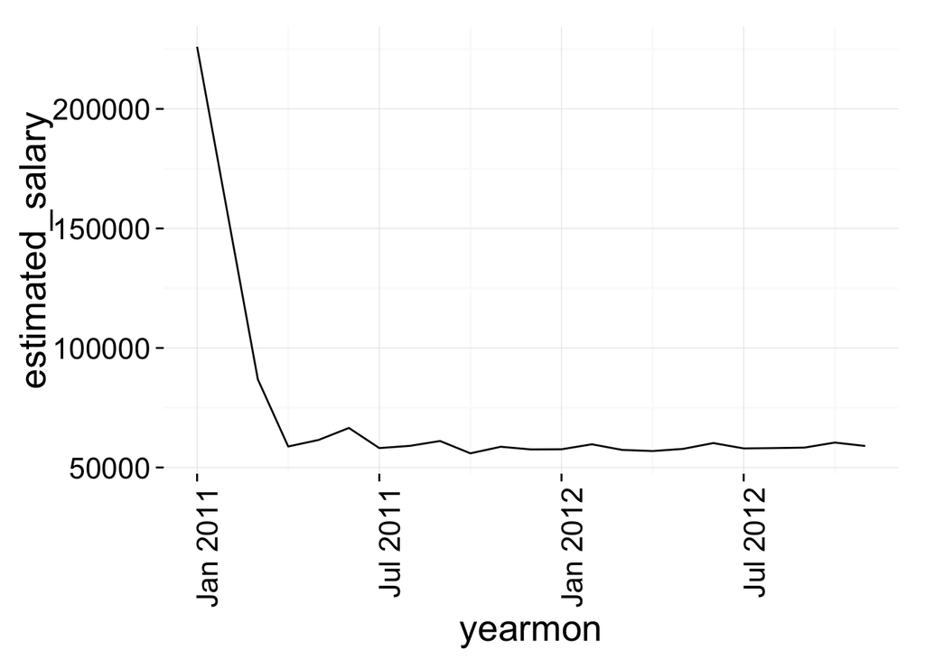

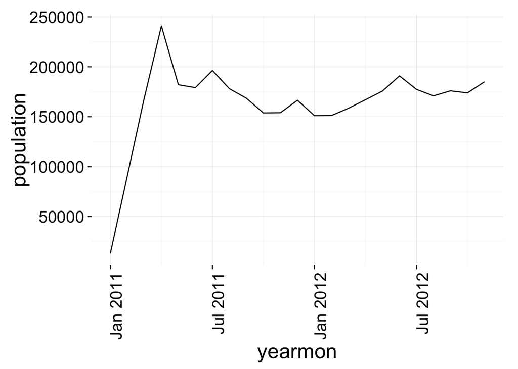

# Bivariate Analysis

### Talk about some of the relationships you observed in this part of the investigation. How did the feature(s) of interest vary with other features in the dataset?

It appears that contributions made to Republicans were higher than those made to Democrats; however, Democrats received a greater number of contributions. The gender breakdown shows that amongst donations made to Democrats, females made more contributions than males. Looking at Republican contributions, males made more contributions than females. This makes sense as females are more likely to identify with Democrats (http://www.people-press.org/2012/06/04/section-9-trends-in-party-affiliation/).

### Did you observe any interesting relationships between the other features (not the main feature(s) of interest)?

### What was the strongest relationship you found?

# Multivariate Plots Section

```
## stat_bin: binwidth defaulted to range/30. Use 'binwidth = x' to adjust this.
## stat_bin: binwidth defaulted to range/30. Use 'binwidth = x' to adjust this.
```

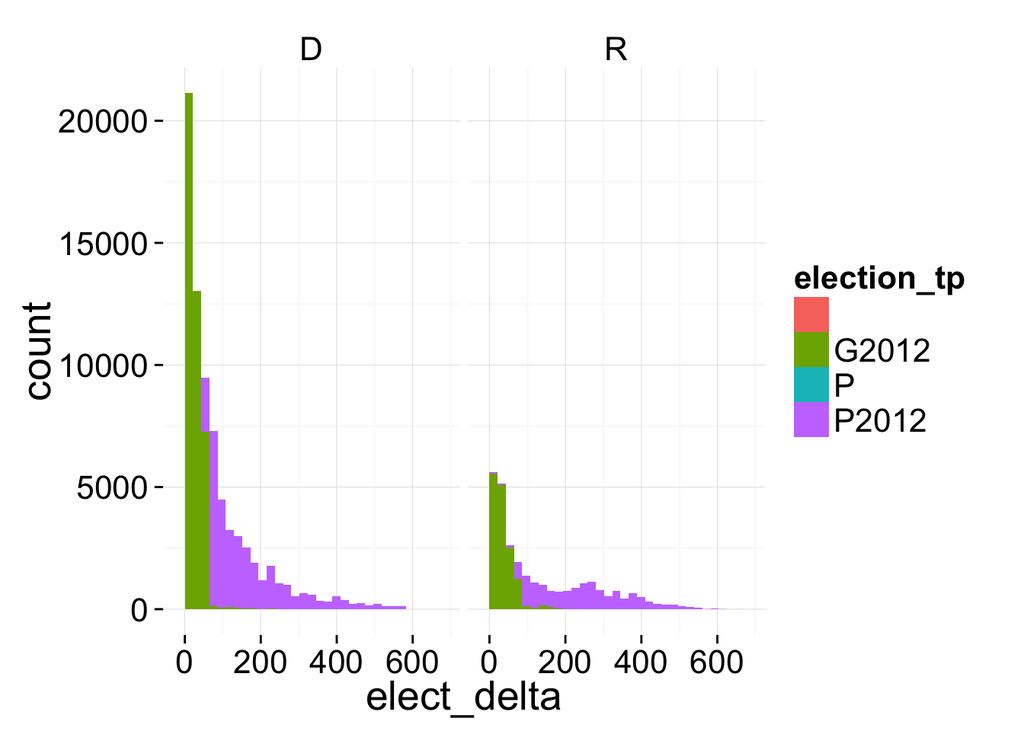

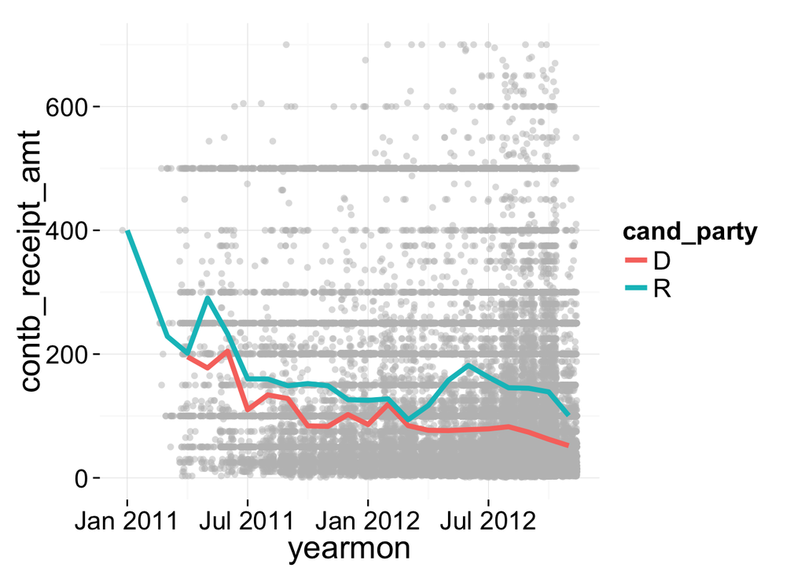

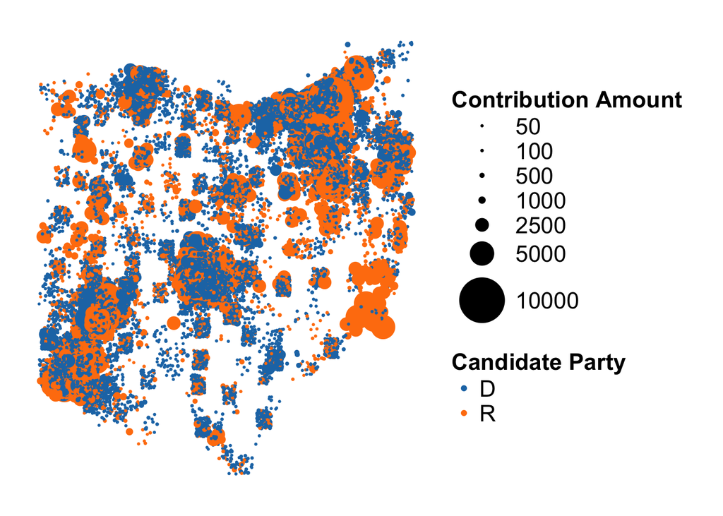

The map makes it easy to spot the most populated cities in Ohio. The center mass is Columbus and to its left, you can see a cluster which contains Dayton at the top and Cincinatti at the bottom. The top right cluster is the Cleveland area and the top left is Toledo. The size of each point indicates the amount of the contribution. Contributions to Republicans appear to be larger than contributions to Democrats. However, there are more contributions made to Democrats than Republicans.

# Multivariate Analysis

### Talk about some of the relationships you observed in this part of the investigation. Were there features that strengthened each other in terms of looking at your feature(s) of interest?

### Were there any interesting or surprising interactions between features?

# Predicting to which Party the Contribution was Made via Logistic Regression

Because I am trying to classify if the contributor donated to a Democrat or Republican, logistic regression is an appropriate model with which to start. Logistic regression uses a a set of covariates to predict probabilities of (binary) class membership. We can then set a threshold to map these probabilities to class labels to solve the classification problem.

### Logistic Regression in Detail

Logistic regression is an extension of the linear regression model with two important differences:

##### 1) Outcome Variable Key to any regression problem is the conditional mean of the outcome variable y given x. In linear regression, we assume that the conditional mean is a linear function taking values in $(-\infty, \infty)$: ${E(y|x) =}\; \alpha + \beta{x}$ Unlike linear regression, the outcome variable of logistic regression has a conditional mean that takes values within [0,1]. In order to extend the linear regression model to logistic regression, we must map the outcome variable $E(y|x)$ into [0,1] via a transformation called the logistic function. ${E(y|x) =}\;\pi(x) = {e^\alpha+\beta{x}\over 1 + e^{\alpha+\beta{x}}}$ The logit function or log-odds function is a transformation of the logistic function. It can be useful in helping interpret the results. ${g(x)=}\; \ln({\pi(x)\over {1-\pi(x)}}) = \alpha + \beta{x}$

##### 2) Error Terms One of the key assumptions of linear regression is that the error terms follow independent Gaussian distributions with zero mean and constant variance. In logistic regression, the outcome variable can only be 0 or 1. Because of this, we can see that the error terms of logistic regression follow a Bernoulli distribution: $\epsilon \sim \beta(0,\pi(1 - \pi))$

#### Interpreting Results

In linear regression, the parameter $\beta$ represents the change in the response variable for a unit change in the covariate. In logistic regression, $\beta$ represents the change in the logit function for a unit change in the covariate. To interpret this change, we must define odds ratio.

The odds ratio of a binary event is given by the odds of the event divided by the odds of its complement: ${OR =}\; {O(x=1)\over{O(x=0)}} = {\pi(i)/(1-\pi(1))\over{\pi(i)/(0-\pi(0))}}$

Substituting the definition of $\pi(x)$ into this equation yields ${OR = }\; \epsilon^\beta$ The relationship between the odds ratio and $\beta$ is what makes logistic regression such a powerful tool.

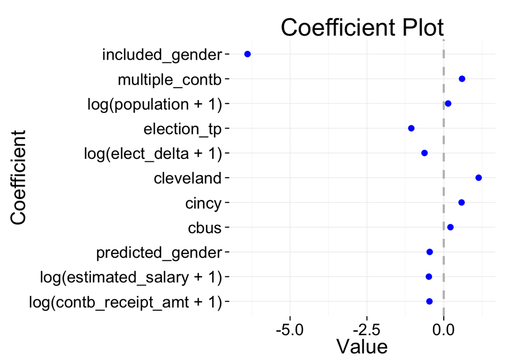

```r
# prepare the data set
glm.data <- data[c(11, 19, 20, 21, 22, 26, 28, 29, 30, 31, 32, 33)]
# this is America, third parties get ignored
glm.data <- subset(glm.data, cand_party == 'D' | cand_party == 'R')
glm.data <- na.omit(glm.data)
glm.data$cand_party <- ifelse(glm.data$cand_party == 'D', 1, 0)
glm.data$predicted_gender <- ifelse(glm.data$predicted_gender == 'male',1,0)
glm.data$election_tp <- ifelse(glm.data$election_tp == 'G2012',1,0)


smp_size <- floor(0.75 * nrow(glm.data))
## set the seed to make your partition reproductible
set.seed(1)
train_ind <- sample(seq_len(nrow(glm.data)), size = smp_size)
train <- glm.data[train_ind, ]
test <- glm.data[-train_ind, ]

fit <- glm(cand_party ~ log(contb_receipt_amt + 1) + log(estimated_salary+1) + predicted_gender   + cbus + cincy + cleveland   + log(elect_delta + 1) + election_tp +  log(population+1) + multiple_contb + included_gender, data=train, family="binomial")
predpr <- predict(fit, newdata=test,type="response")
test$predicted <- predpr
coefplot(fit,intercept=FALSE)
```

###Evaluating Performance There are different ways to evaluate the performance a logistic regression model. I chose to use two techniques, the receiver operating characterstic (ROC) curve and cross-validation.

#### ROC Curve

In our ROC curve, we will see the proportion correctly identified as Democrats plotted against the proportion incorrectly identified as Democrats.

Does the model do a good job of detecting those contributions made to Democrats Our logistic regression model is not predicting if the contribution was made to Democrats or if the contribution was made to Republicans. Instead, it is only predicting if the contribution was made to Democrats. If the model predicts that the contribution was not made to Democrats, then the prediction will be the other choice which is Republicans in our case. (http://stats.stackexchange.com/questions/49469/how-do-i-compute-a-cutoff-based-on-sensitivity-specificity-when-the-characterist) While it is possible to provide specific details about the truth and false positive rates, it should suffice to say that we can think of the truth positive rate as correctly classified and the false positive rate as incorrectly classified. Plotting the true positive rate against the false positive rate will show the ROC curve and by calculating the area under this curve (AUC), we are able to evaluate the performance of our model. The more area under the ROC curve indicates greater predictive power: - auc of 0.5 = no predictive power - auc of 1.0 = perfect predictive power

The closer the curve follows the left-hand border and then the top border of the ROC space, the more accurate the test (http://gim.unmc.edu/dxtests/roc2.htm)

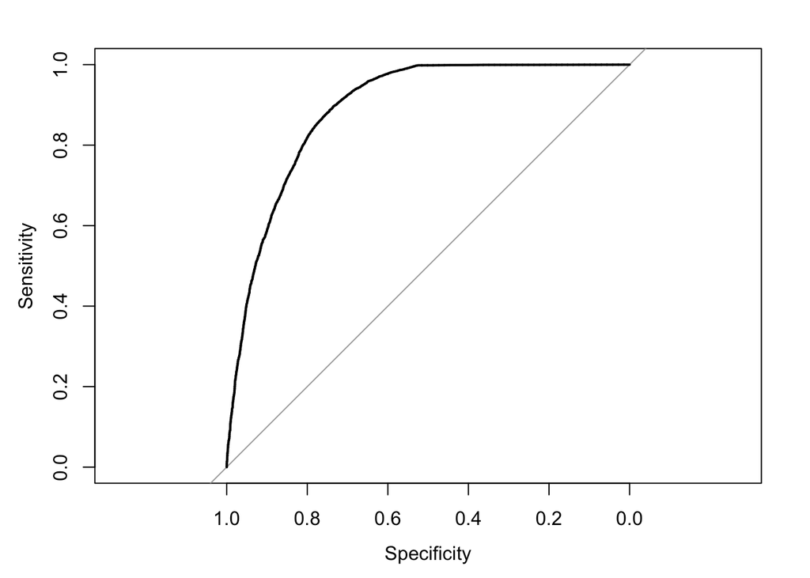

```
##
## Call:
## roc.formula(formula = test$cand_party ~ predpr)
##
## Data: predpr in 7158 controls (test$cand_party 0) < 18996 cases (test$cand_party 1).
## Area under the curve: 0.89
```

```r
glm.roc <- roc(test$cand_party ~ predpr)
plot(glm.roc)
```

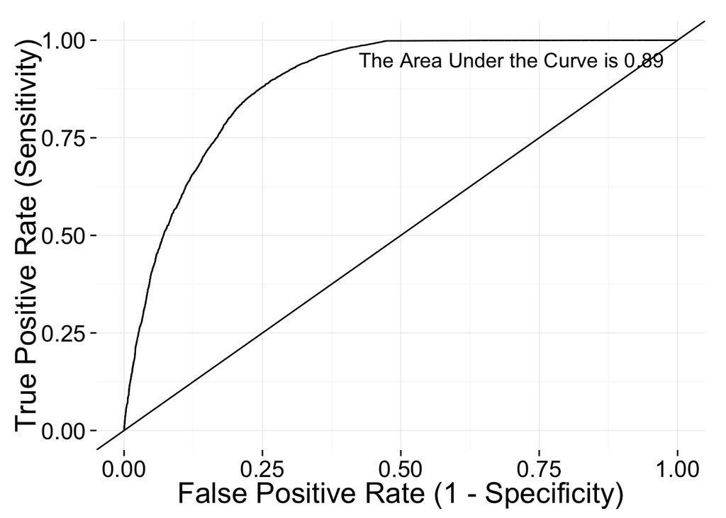

```r
auc <- round(glm.roc$auc,2)
roc.df <- data.frame(specificities=glm.roc$specificities,sensitivities = glm.roc$sensitivities)

roc.plot <- ggplot(roc.df,aes(1-specificities, sensitivities)) + geom_line(aes(), size=0.5) + geom_abline(intercept = 0) + xlab('False Positive Rate (1 - Specificity)') + ylab('True Positive Rate (Sensitivity)') + annotate("text",x=.7,y=0.95,label=paste('The Area Under the Curve is',auc))
roc.plot
```

#### Cross-validation

```r
cv.fit <- cv.glm(train, fit, K=10)
cv.error <- cv.fit$delta
print(cv.error)
```

```
## [1] 0.09619579 0.09619352
```

The second method I will use to evaluate my model is cross-validation, specifically a K-Fold Cross-Validation. Cross-validation involves the following steps: - Randomly split the dataset into n equal partitions. - Use partition 1 as test set & union of other partitions as training set. - Find generalization error. -Repeat steps 2-3 using a different partition as the test set at each iteration. - Take the average generalization error as the estimate of out-of-sample accuracy.

### OPTIONAL: Did you create any models with your dataset? Discuss the strengths and limitations of your model.

# Final Plots and Summary

# Reflection